# Part 2

Eric Langowski

# 1 Introduction

The Detroit housing market has experienced historic levels of foreclosures, disinvestment, and demolitions. Over 1 in 4 properties has been foreclosed due to property tax foreclosure since 2011 and many of these foreclosures were due to inaccurate, inflated assessments. These assessments remain problematic even after the City of Detroit undertook its first citywide reassessment in over 60 years which became effective in 2017.

Since the beginning of the coronavirus pandemic, tax foreclosures have been halted and assessments have become more accurate. Detroit’s housing market has begun to recover with some neighborhoods even gentrifying. Yet, the system remains inequitable especially for low-income homeowners of color.

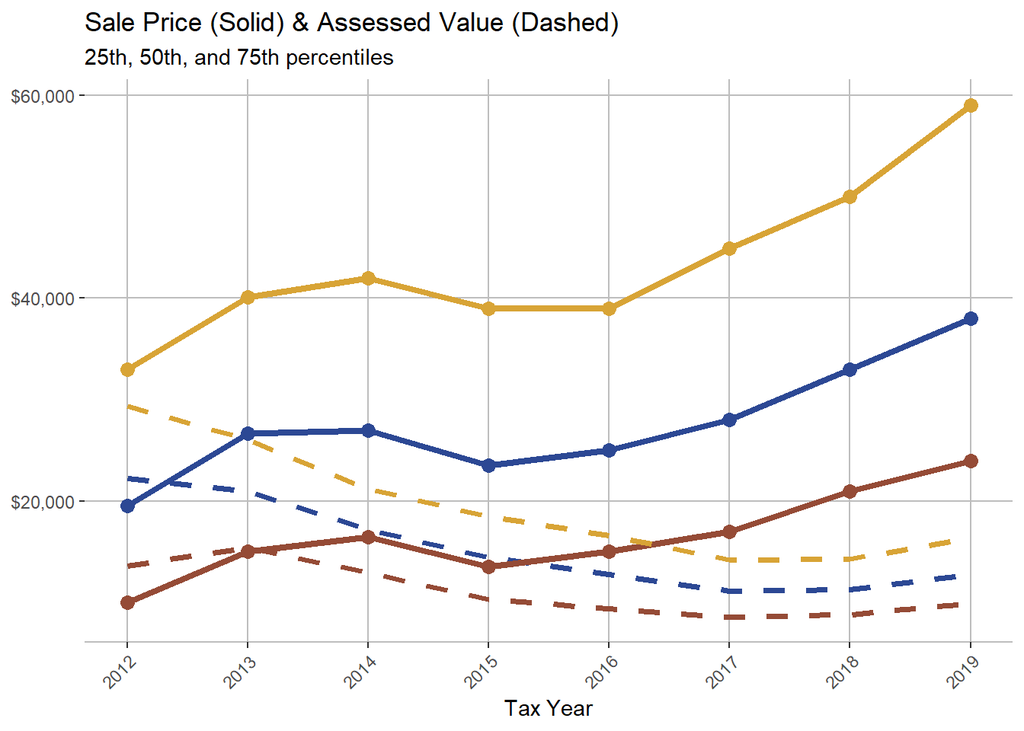

```r
output[[2]]
```

This analysis focuses on single family homes (class 401) which were taxable, sold for more than $2000, and marked as arm’s length by the assessor. Additionally, using the `cmfproperty` package, the IAAO arm’s length standard was applied to the data. This will present a conservative picture of the housing market in Detroit. Note that homes in Detroit as supposed to be assessed at most at 50% of their fair market value.

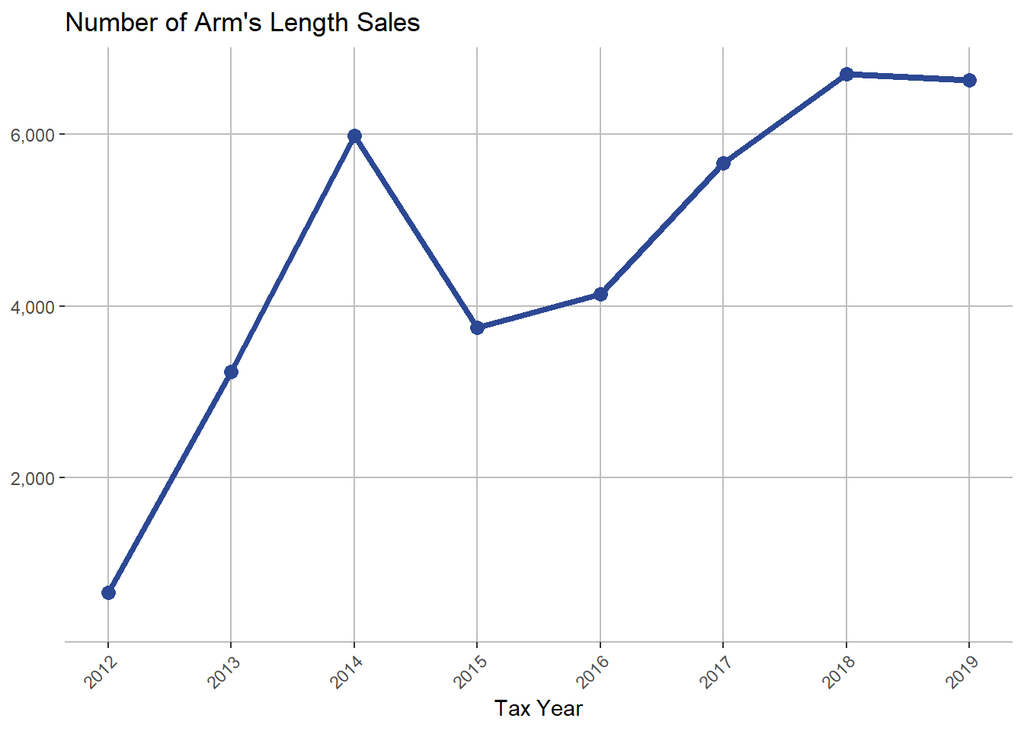

```r
output[[1]]
```

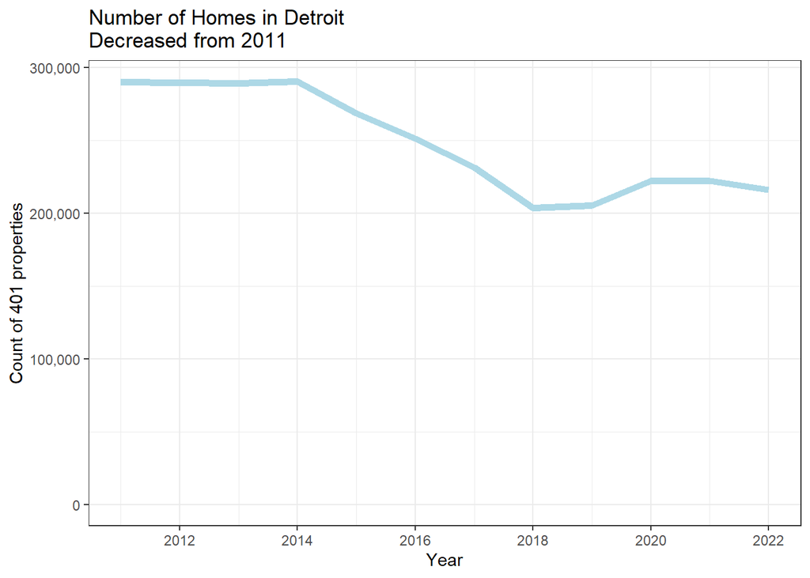

```r
homes_counts <- dplyr::tbl(con, 'assessments') %>% filter(propclass == 401) %>%
  count(year) %>% collect()

ggplot(homes_counts, aes(x=year, y=n)) +
  geom_line(color='light blue', size=2) +
  scale_y_continuous(labels=scales::comma, limit=c(0, NA)) +
  scale_x_continuous(breaks=scales::pretty_breaks()) +
  labs(x='Year', y='Count of 401 properties', title='Number of Homes in Detroit \nDecreased from 2011')
```

# 2 Sales Ratio Analysis

```r
iaao <- cmfproperty::iaao_graphs(stats=stats, ratios=ratios, min_reporting_yr = 2012, max_reporting_yr = 2019, jurisdiction_name = 'Detroit')
```

For 2019, the COD in Detroit was 42.11 which **did not meet** the IAAO standard for uniformity.

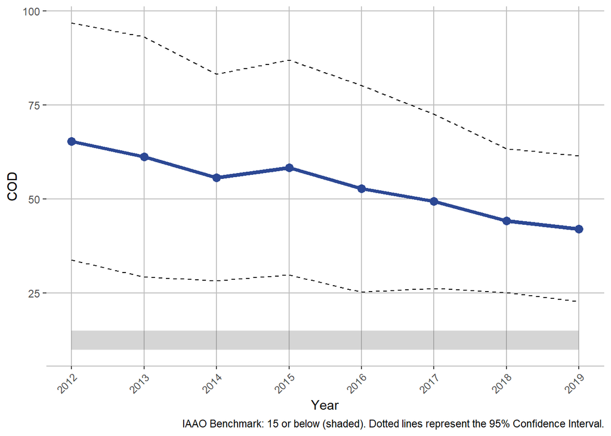

```r
iaao[[2]]
```

In 2019, the PRD in Detroit, was 1.217 which **does not meet** the IAAO standard for vertical equity.

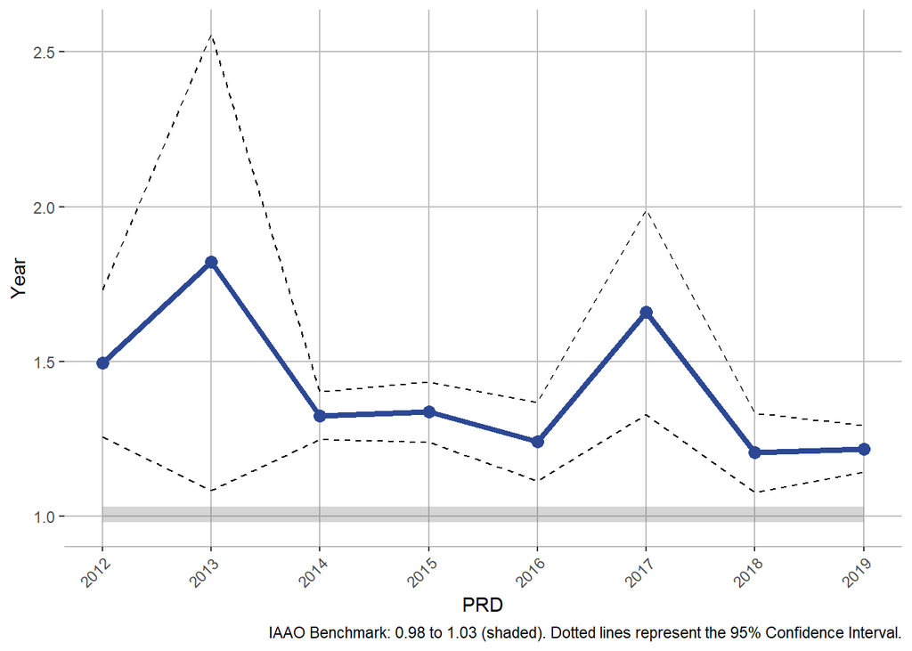

```r
iaao[[4]]
```

In 2019, the PRB in Detroit was -0.354 which indicates that sales ratios decrease by 35.4% when home values double. This **does not meet** the IAAO standard.

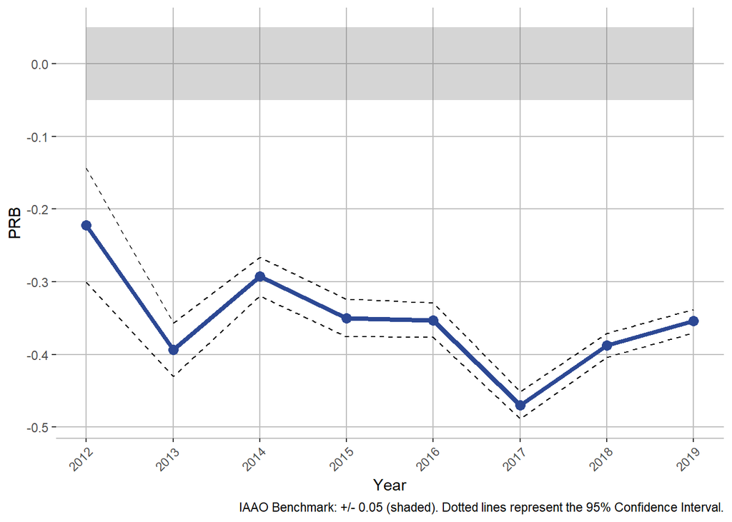

```r
iaao[[6]]
```

```r
bs <- cmfproperty::binned_scatter(ratios = ratios, min_reporting_yr = 2012, max_reporting_yr = 2019, jurisdiction_name = 'Detroit')
```

In 2019, the most expensive homes (the top decile) were assessed at 22.9% of their value and the least expensive homes (the bottom decile) were assessed at 72.6%. In other words, the least expensive homes were assessed at **3.18 times** the rate applied to the most expensive homes. Across our sample from 2012 to 2019, the most expensive homes were assessed at 27.1% of their value and the least expensive homes were assessed at 111.8%, which is **4.12 times** the rate applied to the most expensive homes.

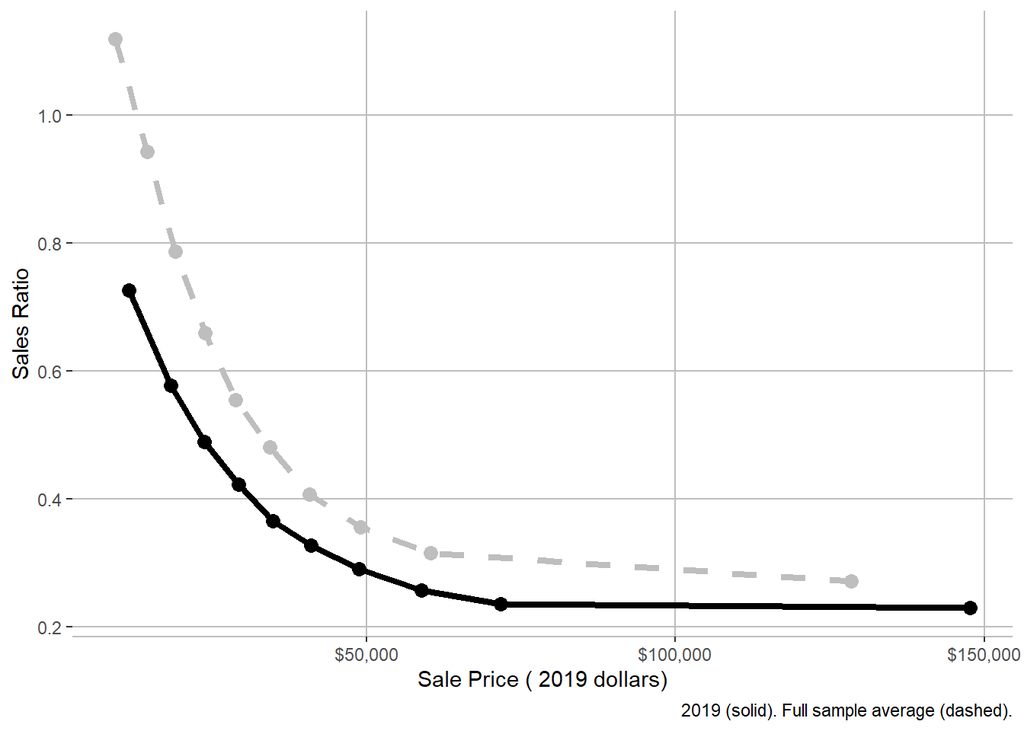

```r
bs[[2]]
```

# 3 Modeling Overassessment

We have multiple questions to consider when modeling overassessment. First, we can only accurately judge if a home was overassessed if it sold. Second, since assessments were generally high, even though a ratio of 50% is the ‘perfect’ assessment, a cutoff of 50% may not truly be the best way to model overassessment.

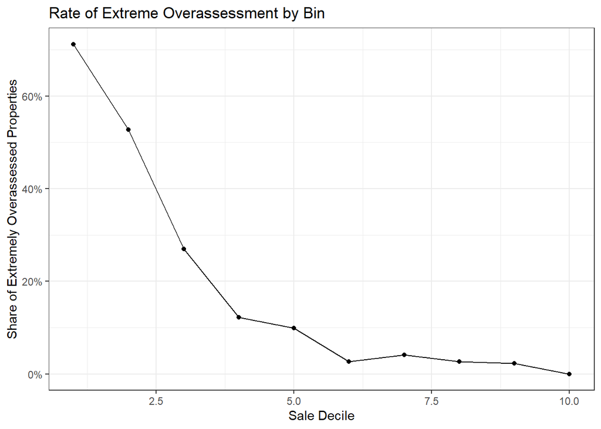

```r
gdata_16 <- ratios %>% filter(SALE_YEAR == 2016) %>%
  group_by(sale_bin = ntile(SALE_PRICE, 10)) %>%
  summarize(`Percent Over 50%` = length(parcel_num[RATIO > .5]) / n(),
            `Percent Over 100%` = length(parcel_num[RATIO > 1]) / length(parcel_num[RATIO > .5]))

ggplot(gdata_16, aes(x=sale_bin, y=`Percent Over 100%`)) +
  geom_point() + geom_line() +
  labs(x='Sale Decile', title='Rate of Extreme Overassessment by Bin',
       y='Share of Extremely Overassessed Properties') +
  scale_y_continuous(labels=percent)
```

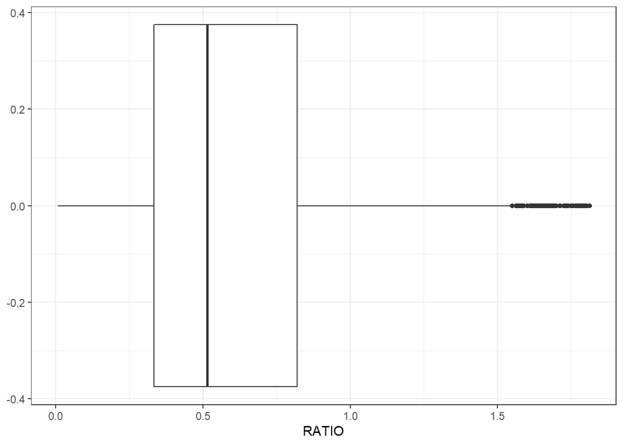

```r
ggplot(ratios %>% filter(SALE_YEAR == 2016), aes(x=RATIO)) + geom_boxplot()
```

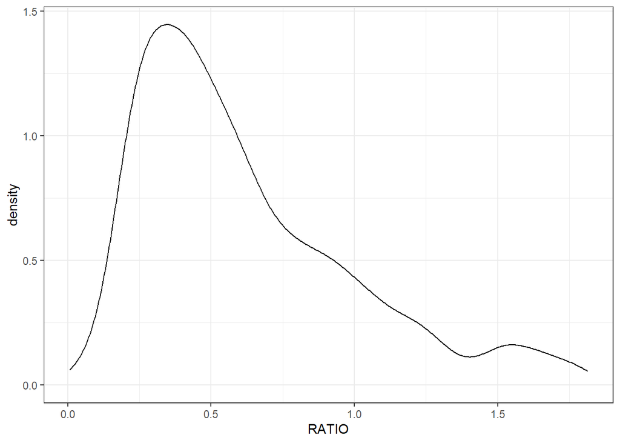

```r
ggplot(ratios %>% filter(SALE_YEAR == 2016), aes(x=RATIO)) + geom_density()
```

## 3.1 Creating Classes

About 33% of ratios are less than .4, 33% are between .4 and .67, and 33% are above .67. It is clear that there are significant differences between a ratio of 1 and .2, but any boundary we select will create difficulties predicting class differences where ratios of say .49 and .51 are on different sides of the boundary.

Let’s try three classifications schemes.

First, in order to capture some of this variability between high and low ratios, let’s choose multiple classes arbitrarily:

Second, just let underassessed be ratio <= .5 and overassessed be ratio > .5.

Third, have extremely overassessed properties have ratio >= .8 with other properties ratio < .8

```r
targ_ratios <- ratios %>% filter(between(SALE_YEAR, 2014, 2019)) %>%
  mutate(class = case_when(
    RATIO <= .4 ~ 'Under',
    RATIO <= .67 ~ 'Normal',
    TRUE ~ 'Over'
  ),
  class = factor(class, levels = c('Under', 'Normal', 'Over')),
  class2 = if_else(RATIO <= .5, 'Under', 'Over'),
  class3 = if_else(RATIO <= .8, 'Under', 'Over'))
```

### 3.1.1 Classification Counts for Method 1

```r
targ_ratios %>% count(class) %>%
  kableExtra::kable() %>%
  kableExtra::kable_material(c("striped", "hover"))
```

| class | n |
| --- | --- |
| Under | 15086 |
| Normal | 9159 |
| Over | 8631 |

### 3.1.2 Classification Counts for Method 2

```r
targ_ratios %>% count(class2) %>%
  kableExtra::kable() %>%
  kableExtra::kable_material(c("striped", "hover"))
```

| class2 | n |
| --- | --- |
| Over | 13427 |
| Under | 19449 |

### 3.1.3 Classification Counts for Method 3

```r
targ_ratios %>% count(class3) %>%
  kableExtra::kable() %>%
  kableExtra::kable_material(c("striped", "hover"))
```

| class3 | n |
| --- | --- |
| Over | 6224 |
| Under | 26652 |

## 3.2 Specifications

```r
joined_ratios <-
  targ_ratios %>%
  select(parcel_num,
         sale_date,
         SALE_PRICE,
         ecf,
         ASSESSED_VALUE,
         TAXABLEVALUE,
         RATIO,
         class, class2, class3,
         SALE_YEAR) %>%
  mutate(sale_date = ymd(sale_date)) %>%
  left_join(
    dplyr::tbl(con, 'parcels') %>% select(
      parcel_number,
      zip_code,
      total_square_footage,
      total_acreage,
      frontage,
      depth,
      total_floor_area,
      year_built,
      X,
      Y
    ) %>% distinct() %>% collect(),
    by=c('parcel_num'='parcel_number')
  ) %>%
  filter(!is.na(X)) %>% tibble() %>%
  mutate(sp_log = log10(SALE_PRICE))

joined_classification <- joined_ratios %>% filter(SALE_YEAR == 2016)
```

Combining information from the sales, assessments, and parcels table, our formula is:

`class ~ total_square_footage + ASSESSED_VALUE + year_built + X + Y`

```r
cor_output %>%
  kableExtra::kable() %>%
  kableExtra::kable_material(c("striped", "hover"))
```

| term | total_square_footage | ASSESSED_VALUE | year_built | X | Y |
| --- | --- | --- | --- | --- | --- |
| total_square_footage |  | .41 | .18 | -.11 | .14 |
| ASSESSED_VALUE | .41 |  | .09 | -.04 | .14 |
| year_built | .18 | .09 |  | -.18 | .36 |
| X | -.11 | -.04 | -.18 |  | .20 |
| Y | .14 | .14 | .36 | .20 |  |

Since we don’t have a lot of arm’s length sales in 2016 (about 4200), we may want to use a training method which resamples our data. Initially, I will use 10-fold cross validation to train and aggregate ten models. For our classification model, we will initially use a random forest of 500 trees. More on that later.

### 3.2.1 Recipie

```
recipe(class ~
  parcel_num + total_square_footage + ASSESSED_VALUE +
  year_built + X + Y,
  data=joined_classification) %>%
  update_role(parcel_num, new_role = 'PARCELID') %>%
  step_log(ASSESSED_VALUE) %>%
  step_interact(~c(ASSESSED_VALUE, total_square_footage, X, Y)) %>%
  step_impute_linear(total_square_footage, year_built, X, Y) %>%
  step_ns(X, Y) %>%
  prep()
```

Our recipe is above. Key steps highlighted:

- Logging assessed value, ensures we capture variability in assessed value which ranges from 1000 to 120000.
- Imputing missing values for total square footage and year built. About fifty sales do not have values for these fields and a simple imputation method is used.
- Create a spline term for latitude and longitude, since lat/lon have a nonlinear relationship with assessed value. Doesn’t make a huge difference.

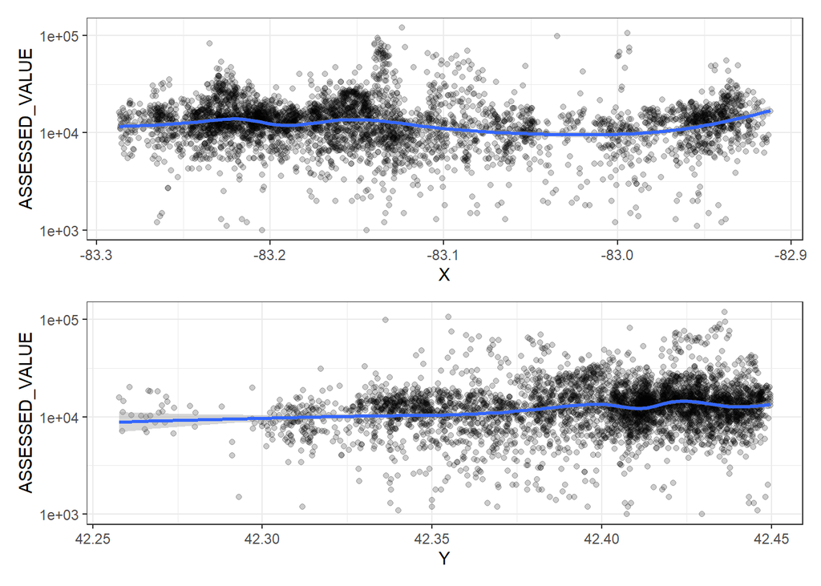

## 3.3 Workflow Prep

Our `tidymodels` workflow requires a model, formula, and recipe. Some of these pieces will be the same across our three specifications.

```r
folds <- rsample::vfold_cv(joined_classification, v = 10)

class_model <-
  rand_forest(trees = 500) %>%
  set_mode('classification') %>%
  set_engine('ranger')


class_recipie <- recipe(class + class2 + class3 ~
                          parcel_num + total_square_footage + ASSESSED_VALUE +
                         year_built + X + Y,
                       data=joined_classification) %>%
  update_role(parcel_num, new_role = 'PARCELID') %>%
  step_log(ASSESSED_VALUE) %>%
  step_interact(~c(ASSESSED_VALUE, total_square_footage, X, Y)) %>%
  step_impute_linear(total_square_footage, year_built, X, Y) %>%
  step_ns(X, Y, deg_free = 20) %>%
  prep()

class_recipie %>% summary()
```

| variable | type | role | source |
| --- | --- | --- | --- |
| parcel_num | nominal | PARCELID | original |
| total_square_footage | numeric | predictor | original |
| ASSESSED_VALUE | numeric | predictor | original |
| year_built | numeric | predictor | original |
| class | nominal | outcome | original |
| class2 | nominal | outcome | original |
| class3 | nominal | outcome | original |
| X_ns_01 | numeric | predictor | derived |
| X_ns_02 | numeric | predictor | derived |
| X_ns_03 | numeric | predictor | derived |

[output cut: 37 more lines]

## 3.4 Specification 1, Multi Class

```r
first_workflow <-
  workflow() %>%
  add_model(class_model) %>%
  add_recipe(class_recipie %>%
               update_role(class2, new_role='not used') %>%
               update_role(class3, new_role='not used'))
model_fit <- first_workflow %>%
  fit_resamples(folds, control=control_resamples(save_pred=TRUE))
```

```r
#collect_metrics(model_fit, summarize=FALSE)
our_results <- collect_metrics(model_fit, summarize=TRUE)
our_results %>%
  kableExtra::kable() %>%
  kableExtra::kable_material(c("striped", "hover"))
```

| .metric | .estimator | mean | n | std_err | .config |
| --- | --- | --- | --- | --- | --- |
| accuracy | multiclass | 0.4368039 | 10 | 0.0059441 | Preprocessor1_Model1 |
| roc_auc | hand_till | 0.6174931 | 10 | 0.0043356 | Preprocessor1_Model1 |

```r
#collect_predictions(model_fit)
our_preds <- collect_predictions(model_fit, summarize=TRUE)
our_preds %>%
  count(.pred_class) %>%
  kableExtra::kable() %>%
  kableExtra::kable_material(c("striped", "hover"))
```

| .pred_class | n |
| --- | --- |
| Under | 1621 |
| Normal | 1022 |
| Over | 1487 |

```r
conf_mat(our_preds, estimate=.pred_class, truth=class)
```

```
##           Truth
## Prediction Under Normal Over
##     Under    793    417  411
##     Normal   272    377  373
##     Over     377    476  634
```

## 3.5 Specification 2, Binary

```r
second_workflow <-
  workflow() %>%
  add_model(class_model) %>%
  add_recipe(class_recipie %>%
               update_role(class, new_role='not used') %>%
               update_role(class3, new_role='not used'))
model_fit2 <- second_workflow %>%
  fit_resamples(folds, control=control_resamples(save_pred=TRUE))
```

```r
our_results <- collect_metrics(model_fit2, summarize=TRUE)
our_results %>%
  kableExtra::kable() %>%
  kableExtra::kable_material(c("striped", "hover"))
```

| .metric | .estimator | mean | n | std_err | .config |
| --- | --- | --- | --- | --- | --- |
| accuracy | binary | 0.5912833 | 10 | 0.0073424 | Preprocessor1_Model1 |
| roc_auc | binary | 0.6313708 | 10 | 0.0088035 | Preprocessor1_Model1 |

```r
our_preds <- collect_predictions(model_fit2, summarize=TRUE)
our_preds %>%
  count(.pred_class) %>%
  kableExtra::kable() %>%
  kableExtra::kable_material(c("striped", "hover"))
```

| .pred_class | n |
| --- | --- |
| Over | 2217 |
| Under | 1913 |

```r
conf_mat(our_preds, estimate=.pred_class, truth=class2)
```

```
##           Truth
## Prediction Over Under
##      Over  1330   887
##      Under  801  1112
```

Better but not great still!

## 3.6 Specification 3, Binary cutoff at .8

```r
third_workflow <-
  workflow() %>%
  add_model(class_model) %>%
  add_recipe(class_recipie %>%
               update_role(class, new_role='not used') %>%
               update_role(class2, new_role='not used'))
model_fit3 <- third_workflow %>%
  fit_resamples(folds, control=control_resamples(save_pred=TRUE))
```

```r
our_results <- collect_metrics(model_fit3, summarize=TRUE)
our_results %>%
  kableExtra::kable() %>%
  kableExtra::kable_material(c("striped", "hover"))
```

| .metric | .estimator | mean | n | std_err | .config |
| --- | --- | --- | --- | --- | --- |
| accuracy | binary | 0.7363196 | 10 | 0.0076522 | Preprocessor1_Model1 |
| roc_auc | binary | 0.6142417 | 10 | 0.0092169 | Preprocessor1_Model1 |

```r
our_preds <- collect_predictions(model_fit3, summarize=TRUE)
our_preds %>%
  count(.pred_class) %>%
  kableExtra::kable() %>%
  kableExtra::kable_material(c("striped", "hover"))
```

| .pred_class | n |
| --- | --- |
| Over | 256 |
| Under | 3874 |

```r
conf_mat(our_preds, estimate=.pred_class, truth=class3)
```

```
##           Truth
## Prediction Over Under
##      Over   119   137
##      Under  952  2922
```

Lots of incorrectly predicted classes here.

## 3.7 Classifier Accuracy Metrics

Based on our three possible specifications, I’m going to analyze specification two for now.

```r
our_preds <- collect_predictions(model_fit2, summarize=TRUE)
multi_metric <- metric_set(recall, specificity, precision, accuracy, f_meas)
multi_metric(our_preds, truth=class2, estimate=.pred_class) %>%
  kableExtra::kable() %>%
  kableExtra::kable_material(c("striped", "hover"))
```

| .metric | .estimator | .estimate |
| --- | --- | --- |
| recall | binary | 0.6241201 |
| specificity | binary | 0.5562781 |
| precision | binary | 0.5999098 |
| accuracy | binary | 0.5912833 |
| f_meas | binary | 0.6117755 |

Some initial views on our model:

```r
joined_classification %>%
  mutate(pred = our_preds$.pred_class,
         bin = ntile(SALE_PRICE, 10)) %>%
  group_by(bin) %>%
  summarize(avg_sp = dollar(mean(SALE_PRICE)),
            share_correct = percent(sum(class2 == pred) / n()),
            share_over = percent(sum(class2 == 'Over') / n()))  %>%
  kableExtra::kable() %>%
  kableExtra::kable_material(c("striped", "hover"))
```

| bin | avg_sp | share_correct | share_over |
| --- | --- | --- | --- |
| 1 | $6,537.67 | 54% | 94% |
| 2 | $10,888.03 | 64% | 89% |
| 3 | $14,779.72 | 65% | 85% |
| 4 | $18,521.82 | 68% | 75% |
| 5 | $22,706.94 | 62% | 64% |
| 6 | $26,898.65 | 61% | 46% |
| 7 | $31,637.01 | 57% | 29% |
| 8 | $38,730.77 | 51% | 18% |
| 9 | $50,132.23 | 47% | 10% |
| 10 | $117,497 | 63% | 5% |

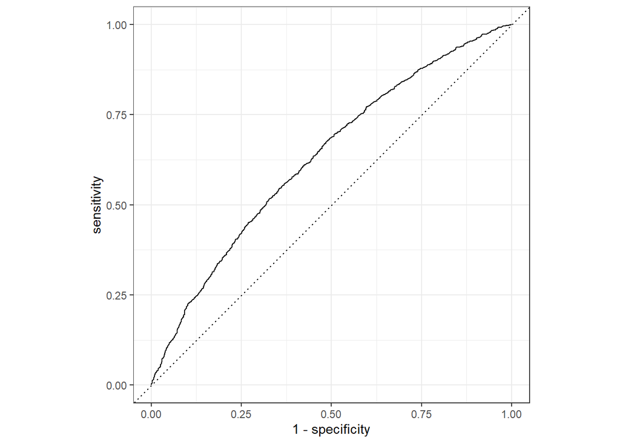

```r
roc_curve(our_preds, class2, .pred_Over) %>%
  autoplot()
```

# 4 Modeling Assessment

```r
time_split <- rsample::initial_time_split(
  joined_ratios %>% filter(between(SALE_YEAR, 2013, 2018)) %>%
    arrange(sale_date),
  .9)

train <- training(time_split)
test <- testing(time_split)

reg_model <- boost_tree(trees=200) %>%
  set_mode('regression') %>%
  set_engine('xgboost')

reg_recipe <- recipe(sp_log ~ total_square_footage +
                         year_built + X + Y + sale_date,
                       data=train) %>%
  step_date(sale_date, features = c("dow", "month", "year"), keep_original_cols = FALSE) %>%
  step_interact(~c(total_square_footage, X, Y)) %>%
  step_impute_linear(total_square_footage, year_built, X, Y) %>%
  step_dummy(all_nominal(), one_hot = TRUE) %>%
  prep()

reg_workflow <-
  workflow() %>%
  add_model(reg_model) %>%
  add_recipe(reg_recipe)
```

## 4.1 Model Evaluation

```r
model_fit_reg <- reg_workflow %>%
  fit(train)

our_preds <- model_fit_reg %>% augment(train)

multi_metric <- metric_set(mape, rmse, rsq)
multi_metric(our_preds, truth=sp_log, estimate=.pred) %>%
  kableExtra::kable() %>%
  kableExtra::kable_material(c("striped", "hover"))
```

| .metric | .estimator | .estimate |
| --- | --- | --- |
| mape | standard | 3.5309607 |
| rmse | standard | 0.1943133 |
| rsq | standard | 0.6467237 |

Our model:

```r
our_preds <- model_fit_reg %>% augment(
  test
)

multi_metric(our_preds, truth=sp_log, estimate=.pred) %>%
  kableExtra::kable() %>%
  kableExtra::kable_material(c("striped", "hover"))
```

| .metric | .estimator | .estimate |
| --- | --- | --- |
| mape | standard | 4.3727647 |
| rmse | standard | 0.2462629 |
| rsq | standard | 0.3514481 |

Actual assessments:

```r
multi_metric(our_preds, truth=log10(2*ASSESSED_VALUE), estimate=.pred) %>%
  kableExtra::kable() %>%
  kableExtra::kable_material(c("striped", "hover"))
```

| .metric | .estimator | .estimate |
| --- | --- | --- |
| mape | standard | 3.7723603 |
| rmse | standard | 0.2110292 |
| rsq | standard | 0.4598078 |

```r
ratios <- cmfproperty::reformat_data(
  our_preds %>% mutate(av_pred = 0.5 * 10^.pred),
  'SALE_PRICE',
  'av_pred',
  'SALE_YEAR'
)
```

```
## [1] "Renaming already present column 'ASSESSED_VALUE' to 'ASSESSED_VALUE_2'."
## [1] "Filtered out non-arm's length transactions"
## [1] "Inflation adjusted to 2018"
```

```r
bs <- cmfproperty::binned_scatter(ratios = ratios, min_reporting_yr = 2018, max_reporting_yr = 2018,
                                  jurisdiction_name = 'Detroit')
```

In 2018, the most expensive homes (the top decile) were assessed at 28.3% of their value and the least expensive homes (the bottom decile) were assessed at 82.8%. In other words, the least expensive homes were assessed at **2.92 times** the rate applied to the most expensive homes. Across our sample from 2018 to 2018, the most expensive homes were assessed at 28.3% of their value and the least expensive homes were assessed at 82.8%, which is **2.92 times** the rate applied to the most expensive homes.

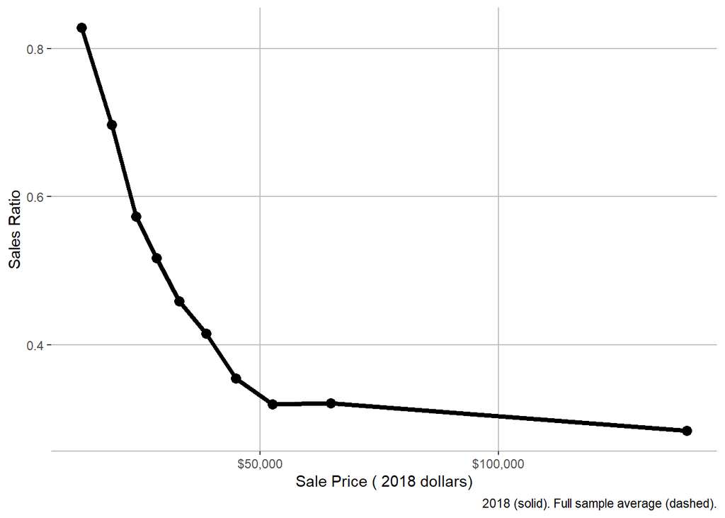

```r
bs[[2]]
```